# Risk Factor Analysis

## Outcome Variable

**Outcome Variable:** stunted

## Predictor Variables

**Intervention Variable:** gagebrth

**Adjustment Set:**

- arm
- sex
- W_mage
- meducyrs
- feducyrs
- hhwealth_quart
- single
- brthmon
- W_parity
- delta_W_mage
- delta_meducyrs
- delta_feducyrs
- delta_hhwealth_quart
- delta_single
- delta_brthmon
- delta_W_parity

## Stratifying Variables

The analysis was stratified on these variable(s):

- agecat
- studyid
- country

## Data Summary

| agecat | studyid | country | gagebrth | stunted | n_cell | n |
| --- | --- | --- | --- | --- | --- | --- |
| Birth | ki1000108-CMC-V-BCS-2002 | INDIA | Full or late term | 0 | 47 | 90 |
| Birth | ki1000108-CMC-V-BCS-2002 | INDIA | Full or late term | 1 | 10 | 90 |
| Birth | ki1000108-CMC-V-BCS-2002 | INDIA | Preterm | 0 | 8 | 90 |
| Birth | ki1000108-CMC-V-BCS-2002 | INDIA | Preterm | 1 | 2 | 90 |
| Birth | ki1000108-CMC-V-BCS-2002 | INDIA | Early term | 0 | 19 | 90 |
| Birth | ki1000108-CMC-V-BCS-2002 | INDIA | Early term | 1 | 4 | 90 |
| Birth | ki1000108-IRC | INDIA | Full or late term | 0 | 211 | 369 |
| Birth | ki1000108-IRC | INDIA | Full or late term | 1 | 27 | 369 |
| Birth | ki1000108-IRC | INDIA | Preterm | 0 | 27 | 369 |
| Birth | ki1000108-IRC | INDIA | Preterm | 1 | 9 | 369 |
| Birth | ki1000108-IRC | INDIA | Early term | 0 | 87 | 369 |
| Birth | ki1000108-IRC | INDIA | Early term | 1 | 8 | 369 |
| Birth | ki1000109-EE | PAKISTAN | Full or late term | 0 | 0 | 2 |
| Birth | ki1000109-EE | PAKISTAN | Full or late term | 1 | 0 | 2 |
| Birth | ki1000109-EE | PAKISTAN | Preterm | 0 | 0 | 2 |
| Birth | ki1000109-EE | PAKISTAN | Preterm | 1 | 1 | 2 |
| Birth | ki1000109-EE | PAKISTAN | Early term | 0 | 1 | 2 |
| Birth | ki1000109-EE | PAKISTAN | Early term | 1 | 0 | 2 |
| Birth | ki1000304b-SAS-CompFeed | INDIA | Full or late term | 0 | 1 | 187 |
| Birth | ki1000304b-SAS-CompFeed | INDIA | Full or late term | 1 | 0 | 187 |
| Birth | ki1000304b-SAS-CompFeed | INDIA | Preterm | 0 | 128 | 187 |
| Birth | ki1000304b-SAS-CompFeed | INDIA | Preterm | 1 | 43 | 187 |
| Birth | ki1000304b-SAS-CompFeed | INDIA | Early term | 0 | 12 | 187 |
| Birth | ki1000304b-SAS-CompFeed | INDIA | Early term | 1 | 3 | 187 |
| Birth | ki1017093c-NIH-Crypto | BANGLADESH | Full or late term | 0 | 5 | 27 |
| Birth | ki1017093c-NIH-Crypto | BANGLADESH | Full or late term | 1 | 2 | 27 |
| Birth | ki1017093c-NIH-Crypto | BANGLADESH | Preterm | 0 | 3 | 27 |
| Birth | ki1017093c-NIH-Crypto | BANGLADESH | Preterm | 1 | 2 | 27 |
| Birth | ki1017093c-NIH-Crypto | BANGLADESH | Early term | 0 | 14 | 27 |
| Birth | ki1017093c-NIH-Crypto | BANGLADESH | Early term | 1 | 1 | 27 |

[output cut: 168 more lines]

The following strata were considered:

- agecat: 24 months, studyid: ki1000108-CMC-V-BCS-2002, country: INDIA
- agecat: 24 months, studyid: ki1000108-IRC, country: INDIA
- agecat: 24 months, studyid: ki1017093c-NIH-Crypto, country: BANGLADESH
- agecat: 24 months, studyid: ki1066203-TanzaniaChild2, country: TANZANIA, UNITED REPUBLIC OF
- agecat: 24 months, studyid: ki1101329-Keneba, country: GAMBIA
- agecat: 24 months, studyid: ki1119695-PROBIT, country: BELARUS
- agecat: 24 months, studyid: ki1135781-COHORTS, country: GUATEMALA
- agecat: 24 months, studyid: ki1135781-COHORTS, country: INDIA
- agecat: 24 months, studyid: ki1135781-COHORTS, country: PHILIPPINES
- agecat: 24 months, studyid: kiGH5241-JiVitA-3, country: BANGLADESH
- agecat: 6 months, studyid: ki1000108-CMC-V-BCS-2002, country: INDIA
- agecat: 6 months, studyid: ki1000108-IRC, country: INDIA
- agecat: 6 months, studyid: ki1000109-EE, country: PAKISTAN
- agecat: 6 months, studyid: ki1000304b-SAS-CompFeed, country: INDIA
- agecat: 6 months, studyid: ki1017093c-NIH-Crypto, country: BANGLADESH
- agecat: 6 months, studyid: ki1066203-TanzaniaChild2, country: TANZANIA, UNITED REPUBLIC OF
- agecat: 6 months, studyid: ki1101329-Keneba, country: GAMBIA
- agecat: 6 months, studyid: ki1119695-PROBIT, country: BELARUS
- agecat: 6 months, studyid: ki1135781-COHORTS, country: GUATEMALA
- agecat: 6 months, studyid: ki1135781-COHORTS, country: INDIA
- agecat: 6 months, studyid: ki1135781-COHORTS, country: PHILIPPINES
- agecat: 6 months, studyid: kiGH5241-JiVitA-3, country: BANGLADESH
- agecat: Birth, studyid: ki1000108-CMC-V-BCS-2002, country: INDIA
- agecat: Birth, studyid: ki1000108-IRC, country: INDIA
- agecat: Birth, studyid: ki1000109-EE, country: PAKISTAN
- agecat: Birth, studyid: ki1000304b-SAS-CompFeed, country: INDIA
- agecat: Birth, studyid: ki1017093c-NIH-Crypto, country: BANGLADESH
- agecat: Birth, studyid: ki1101329-Keneba, country: GAMBIA
- agecat: Birth, studyid: ki1119695-PROBIT, country: BELARUS
- agecat: Birth, studyid: ki1135781-COHORTS, country: GUATEMALA
- agecat: Birth, studyid: ki1135781-COHORTS, country: INDIA
- agecat: Birth, studyid: ki1135781-COHORTS, country: PHILIPPINES
- agecat: Birth, studyid: kiGH5241-JiVitA-3, country: BANGLADESH

### Dropped Strata

Some strata were dropped due to rare outcomes:

- agecat: Birth, studyid: ki1000108-CMC-V-BCS-2002, country: INDIA
- agecat: Birth, studyid: ki1000109-EE, country: PAKISTAN
- agecat: Birth, studyid: ki1000304b-SAS-CompFeed, country: INDIA
- agecat: Birth, studyid: ki1017093c-NIH-Crypto, country: BANGLADESH
- agecat: 6 months, studyid: ki1000304b-SAS-CompFeed, country: INDIA
- agecat: 24 months, studyid: ki1066203-TanzaniaChild2, country: TANZANIA, UNITED REPUBLIC OF

## Methods Detail

We’re interested in the causal parameters $E[Y_a]$ for all values of $a \in \mathcal{A}$. These parameters represent the mean outcome if, possibly contrary to fact, we intervened to set all units to have $A=a$. Under the randomization and positivity assumptions, these are identified by the statistical parameters $\psi_a=E_W[E_{Y|A,W}(Y|A=a,W)]$. In addition, we’re interested in the mean of $Y$, $E[Y]$ under no intervention (the observed mean). We will estimate these parameters by using SuperLearner to fit the relevant likelihood factors – $E_{Y|A,W}(Y|A=a,W)$ and $p(A=a|W)$, and then updating our likelihood fit using a joint TMLE.

For unadjusted analyses ($W=\{\}$), initial likelihoods were estimated using Lrnr_glm to estimate the simple $E(Y|A)$ and Lrnr_mean to estimate $p(A)$. For adjusted analyses, a small library containing Lrnr_glmnet, Lrnr_xgboost, and Lrnr_mean was used.

Having estimated these parameters, we will then use the delta method to estimate relative risks and attributable risks relative to a prespecified baseline level of $A$.

# Results Detail

## Results Plots

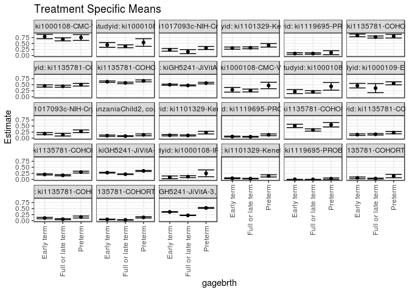

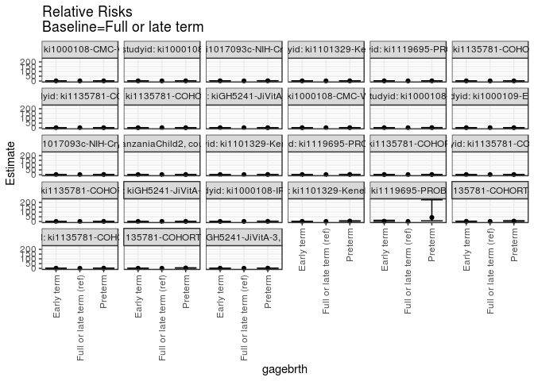

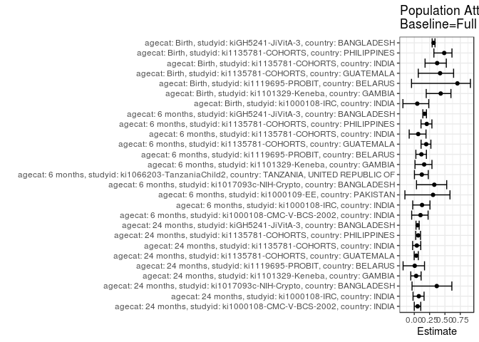

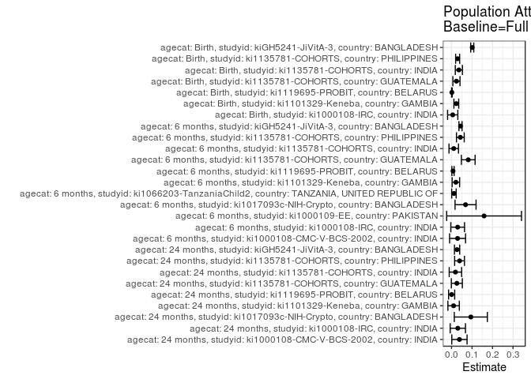

## Results Table

### Parameter: TSM

| agecat | studyid | country | intervention_level | baseline_level | estimate | ci_lower | ci_upper |
| --- | --- | --- | --- | --- | --- | --- | --- |
| Birth | ki1000108-IRC | INDIA | Full or late term | NA | 0.1134454 | 0.0730999 | 0.1537909 |
| Birth | ki1000108-IRC | INDIA | Preterm | NA | 0.2500000 | 0.1083597 | 0.3916403 |
| Birth | ki1000108-IRC | INDIA | Early term | NA | 0.0842105 | 0.0282919 | 0.1401292 |
| Birth | ki1101329-Keneba | GAMBIA | Full or late term | NA | 0.0307898 | 0.0182376 | 0.0433421 |
| Birth | ki1101329-Keneba | GAMBIA | Preterm | NA | 0.1434325 | 0.0986015 | 0.1882635 |
| Birth | ki1101329-Keneba | GAMBIA | Early term | NA | 0.0456735 | 0.0281389 | 0.0632082 |
| Birth | ki1119695-PROBIT | BELARUS | Full or late term | NA | 0.0007047 | -0.0002052 | 0.0016147 |
| Birth | ki1119695-PROBIT | BELARUS | Preterm | NA | 0.0296610 | -0.0004536 | 0.0597756 |
| Birth | ki1119695-PROBIT | BELARUS | Early term | NA | 0.0022162 | 0.0011584 | 0.0032741 |
| Birth | ki1135781-COHORTS | GUATEMALA | Full or late term | NA | 0.0328355 | 0.0137167 | 0.0519542 |
| Birth | ki1135781-COHORTS | GUATEMALA | Preterm | NA | 0.1374987 | 0.0680094 | 0.2069880 |
| Birth | ki1135781-COHORTS | GUATEMALA | Early term | NA | 0.0620057 | 0.0267826 | 0.0972289 |
| Birth | ki1135781-COHORTS | INDIA | Full or late term | NA | 0.0601489 | 0.0407128 | 0.0795851 |
| Birth | ki1135781-COHORTS | INDIA | Preterm | NA | 0.1493562 | 0.1075548 | 0.1911576 |
| Birth | ki1135781-COHORTS | INDIA | Early term | NA | 0.1068224 | 0.0778226 | 0.1358223 |
| Birth | ki1135781-COHORTS | PHILIPPINES | Full or late term | NA | 0.0313146 | 0.0213624 | 0.0412668 |
| Birth | ki1135781-COHORTS | PHILIPPINES | Preterm | NA | 0.1336785 | 0.1072897 | 0.1600672 |
| Birth | ki1135781-COHORTS | PHILIPPINES | Early term | NA | 0.0504257 | 0.0380897 | 0.0627618 |
| Birth | kiGH5241-JiVitA-3 | BANGLADESH | Full or late term | NA | 0.2194984 | 0.2098713 | 0.2291255 |
| Birth | kiGH5241-JiVitA-3 | BANGLADESH | Preterm | NA | 0.5260520 | 0.5085373 | 0.5435668 |
| Birth | kiGH5241-JiVitA-3 | BANGLADESH | Early term | NA | 0.3606507 | 0.3457636 | 0.3755379 |
| 6 months | ki1000108-CMC-V-BCS-2002 | INDIA | Full or late term | NA | 0.2615657 | 0.2024471 | 0.3206843 |
| 6 months | ki1000108-CMC-V-BCS-2002 | INDIA | Preterm | NA | 0.4702333 | 0.3372797 | 0.6031869 |
| 6 months | ki1000108-CMC-V-BCS-2002 | INDIA | Early term | NA | 0.2937283 | 0.1959441 | 0.3915124 |
| 6 months | ki1000108-IRC | INDIA | Full or late term | NA | 0.2071141 | 0.1567458 | 0.2574823 |
| 6 months | ki1000108-IRC | INDIA | Preterm | NA | 0.4362776 | 0.2767564 | 0.5957989 |
| 6 months | ki1000108-IRC | INDIA | Early term | NA | 0.2181591 | 0.1348577 | 0.3014605 |
| 6 months | ki1000109-EE | PAKISTAN | Full or late term | NA | 0.3600000 | 0.1715900 | 0.5484100 |
| 6 months | ki1000109-EE | PAKISTAN | Preterm | NA | 0.5606695 | 0.4976633 | 0.6236756 |
| 6 months | ki1000109-EE | PAKISTAN | Early term | NA | 0.4629630 | 0.3687966 | 0.5571294 |

[output cut: 51 more lines]

### Parameter: E(Y)

| agecat | studyid | country | intervention_level | baseline_level | estimate | ci_lower | ci_upper |
| --- | --- | --- | --- | --- | --- | --- | --- |
| Birth | ki1000108-IRC | INDIA | NA | NA | 0.1192412 | 0.0861307 | 0.1523517 |
| Birth | ki1101329-Keneba | GAMBIA | NA | NA | 0.0541254 | 0.0427281 | 0.0655227 |
| Birth | ki1119695-PROBIT | BELARUS | NA | NA | 0.0023768 | 0.0010945 | 0.0036592 |
| Birth | ki1135781-COHORTS | GUATEMALA | NA | NA | 0.0567261 | 0.0384591 | 0.0749931 |
| Birth | ki1135781-COHORTS | INDIA | NA | NA | 0.0959010 | 0.0798450 | 0.1119570 |
| Birth | ki1135781-COHORTS | PHILIPPINES | NA | NA | 0.0611772 | 0.0526341 | 0.0697204 |
| Birth | kiGH5241-JiVitA-3 | BANGLADESH | NA | NA | 0.3205490 | 0.3127517 | 0.3283463 |
| 6 months | ki1000108-CMC-V-BCS-2002 | INDIA | NA | NA | 0.2910663 | 0.2432023 | 0.3389303 |
| 6 months | ki1000108-IRC | INDIA | NA | NA | 0.2371134 | 0.1947393 | 0.2794875 |
| 6 months | ki1000109-EE | PAKISTAN | NA | NA | 0.5188172 | 0.4679751 | 0.5696593 |
| 6 months | ki1017093c-NIH-Crypto | BANGLADESH | NA | NA | 0.2097902 | 0.1799252 | 0.2396552 |
| 6 months | ki1066203-TanzaniaChild2 | TANZANIA, UNITED REPUBLIC OF | NA | NA | 0.0956385 | 0.0824215 | 0.1088554 |
| 6 months | ki1101329-Keneba | GAMBIA | NA | NA | 0.1317322 | 0.1138432 | 0.1496212 |
| 6 months | ki1119695-PROBIT | BELARUS | NA | NA | 0.0626864 | 0.0488489 | 0.0765238 |
| 6 months | ki1135781-COHORTS | GUATEMALA | NA | NA | 0.4193548 | 0.3831093 | 0.4556004 |
| 6 months | ki1135781-COHORTS | INDIA | NA | NA | 0.1692073 | 0.1489117 | 0.1895030 |
| 6 months | ki1135781-COHORTS | PHILIPPINES | NA | NA | 0.2113882 | 0.1959475 | 0.2268289 |
| 6 months | kiGH5241-JiVitA-3 | BANGLADESH | NA | NA | 0.2583721 | 0.2489533 | 0.2677908 |
| 24 months | ki1000108-CMC-V-BCS-2002 | INDIA | NA | NA | 0.7114286 | 0.6638920 | 0.7589651 |
| 24 months | ki1000108-IRC | INDIA | NA | NA | 0.4153846 | 0.3664142 | 0.4643550 |
| 24 months | ki1017093c-NIH-Crypto | BANGLADESH | NA | NA | 0.2568093 | 0.2190047 | 0.2946140 |
| 24 months | ki1101329-Keneba | GAMBIA | NA | NA | 0.3321799 | 0.3050172 | 0.3593427 |
| 24 months | ki1119695-PROBIT | BELARUS | NA | NA | 0.0852540 | 0.0554439 | 0.1150642 |
| 24 months | ki1135781-COHORTS | GUATEMALA | NA | NA | 0.7948718 | 0.7641122 | 0.8256314 |
| 24 months | ki1135781-COHORTS | INDIA | NA | NA | 0.4579511 | 0.4309402 | 0.4849620 |
| 24 months | ki1135781-COHORTS | PHILIPPINES | NA | NA | 0.6175743 | 0.5982239 | 0.6369246 |
| 24 months | kiGH5241-JiVitA-3 | BANGLADESH | NA | NA | 0.5005390 | 0.4858066 | 0.5152715 |

### Parameter: RR

| agecat | studyid | country | intervention_level | baseline_level | estimate | ci_lower | ci_upper |
| --- | --- | --- | --- | --- | --- | --- | --- |
| Birth | ki1000108-IRC | INDIA | Full or late term | Full or late term | 1.0000000 | 1.0000000 | 1.000000 |
| Birth | ki1000108-IRC | INDIA | Preterm | Full or late term | 2.2037037 | 1.1288592 | 4.301963 |
| Birth | ki1000108-IRC | INDIA | Early term | Full or late term | 0.7423002 | 0.3494922 | 1.576600 |
| Birth | ki1101329-Keneba | GAMBIA | Full or late term | Full or late term | 1.0000000 | 1.0000000 | 1.000000 |
| Birth | ki1101329-Keneba | GAMBIA | Preterm | Full or late term | 4.6584362 | 2.7876039 | 7.784832 |
| Birth | ki1101329-Keneba | GAMBIA | Early term | Full or late term | 1.4833965 | 0.8471009 | 2.597642 |
| Birth | ki1119695-PROBIT | BELARUS | Full or late term | Full or late term | 1.0000000 | 1.0000000 | 1.000000 |
| Birth | ki1119695-PROBIT | BELARUS | Preterm | Full or late term | 42.0889831 | 7.7901583 | 227.400064 |
| Birth | ki1119695-PROBIT | BELARUS | Early term | Full or late term | 3.1448472 | 0.7336051 | 13.481455 |
| Birth | ki1135781-COHORTS | GUATEMALA | Full or late term | Full or late term | 1.0000000 | 1.0000000 | 1.000000 |
| Birth | ki1135781-COHORTS | GUATEMALA | Preterm | Full or late term | 4.1875073 | 1.9368178 | 9.053623 |
| Birth | ki1135781-COHORTS | GUATEMALA | Early term | Full or late term | 1.8883768 | 0.8371722 | 4.259539 |
| Birth | ki1135781-COHORTS | INDIA | Full or late term | Full or late term | 1.0000000 | 1.0000000 | 1.000000 |
| Birth | ki1135781-COHORTS | INDIA | Preterm | Full or late term | 2.4831063 | 1.6200133 | 3.806029 |
| Birth | ki1135781-COHORTS | INDIA | Early term | Full or late term | 1.7759651 | 1.1646456 | 2.708165 |
| Birth | ki1135781-COHORTS | PHILIPPINES | Full or late term | Full or late term | 1.0000000 | 1.0000000 | 1.000000 |
| Birth | ki1135781-COHORTS | PHILIPPINES | Preterm | Full or late term | 4.2688885 | 2.9369519 | 6.204871 |
| Birth | ki1135781-COHORTS | PHILIPPINES | Early term | Full or late term | 1.6102950 | 1.0783708 | 2.404600 |
| Birth | kiGH5241-JiVitA-3 | BANGLADESH | Full or late term | Full or late term | 1.0000000 | 1.0000000 | 1.000000 |
| Birth | kiGH5241-JiVitA-3 | BANGLADESH | Preterm | Full or late term | 2.3966099 | 2.2670715 | 2.533550 |
| Birth | kiGH5241-JiVitA-3 | BANGLADESH | Early term | Full or late term | 1.6430677 | 1.5495049 | 1.742280 |
| 6 months | ki1000108-CMC-V-BCS-2002 | INDIA | Full or late term | Full or late term | 1.0000000 | 1.0000000 | 1.000000 |
| 6 months | ki1000108-CMC-V-BCS-2002 | INDIA | Preterm | Full or late term | 1.7977638 | 1.2518795 | 2.581682 |
| 6 months | ki1000108-CMC-V-BCS-2002 | INDIA | Early term | Full or late term | 1.1229618 | 0.7511356 | 1.678849 |
| 6 months | ki1000108-IRC | INDIA | Full or late term | Full or late term | 1.0000000 | 1.0000000 | 1.000000 |
| 6 months | ki1000108-IRC | INDIA | Preterm | Full or late term | 2.1064607 | 1.3562323 | 3.271694 |
| 6 months | ki1000108-IRC | INDIA | Early term | Full or late term | 1.0533284 | 0.6684560 | 1.659796 |
| 6 months | ki1000109-EE | PAKISTAN | Full or late term | Full or late term | 1.0000000 | 1.0000000 | 1.000000 |
| 6 months | ki1000109-EE | PAKISTAN | Preterm | Full or late term | 1.5574152 | 0.9118659 | 2.659977 |
| 6 months | ki1000109-EE | PAKISTAN | Early term | Full or late term | 1.2860082 | 0.7334813 | 2.254750 |

[output cut: 51 more lines]

### Parameter: PAR

| agecat | studyid | country | intervention_level | baseline_level | estimate | ci_lower | ci_upper |
| --- | --- | --- | --- | --- | --- | --- | --- |
| Birth | ki1000108-IRC | INDIA | Full or late term | NA | 0.0057958 | -0.0191902 | 0.0307818 |
| Birth | ki1101329-Keneba | GAMBIA | Full or late term | NA | 0.0233356 | 0.0115986 | 0.0350725 |
| Birth | ki1119695-PROBIT | BELARUS | Full or late term | NA | 0.0016721 | 0.0003118 | 0.0030325 |
| Birth | ki1135781-COHORTS | GUATEMALA | Full or late term | NA | 0.0238906 | 0.0064933 | 0.0412879 |
| Birth | ki1135781-COHORTS | INDIA | Full or late term | NA | 0.0357521 | 0.0183883 | 0.0531159 |
| Birth | ki1135781-COHORTS | PHILIPPINES | Full or late term | NA | 0.0298627 | 0.0200773 | 0.0396480 |
| Birth | kiGH5241-JiVitA-3 | BANGLADESH | Full or late term | NA | 0.1010506 | 0.0935477 | 0.1085535 |
| 6 months | ki1000108-CMC-V-BCS-2002 | INDIA | Full or late term | NA | 0.0295006 | -0.0094356 | 0.0684368 |
| 6 months | ki1000108-IRC | INDIA | Full or late term | NA | 0.0299993 | -0.0035044 | 0.0635031 |
| 6 months | ki1000109-EE | PAKISTAN | Full or late term | NA | 0.1588172 | -0.0236984 | 0.3413328 |
| 6 months | ki1017093c-NIH-Crypto | BANGLADESH | Full or late term | NA | 0.0684550 | 0.0171879 | 0.1197221 |
| 6 months | ki1066203-TanzaniaChild2 | TANZANIA, UNITED REPUBLIC OF | Full or late term | NA | 0.0117375 | 0.0008754 | 0.0225995 |
| 6 months | ki1101329-Keneba | GAMBIA | Full or late term | NA | 0.0212481 | 0.0029754 | 0.0395208 |
| 6 months | ki1119695-PROBIT | BELARUS | Full or late term | NA | 0.0072756 | 0.0017833 | 0.0127679 |
| 6 months | ki1135781-COHORTS | GUATEMALA | Full or late term | NA | 0.0816340 | 0.0481978 | 0.1150703 |
| 6 months | ki1135781-COHORTS | INDIA | Full or late term | NA | 0.0108350 | -0.0122990 | 0.0339690 |
| 6 months | ki1135781-COHORTS | PHILIPPINES | Full or late term | NA | 0.0430364 | 0.0241347 | 0.0619381 |
| 6 months | kiGH5241-JiVitA-3 | BANGLADESH | Full or late term | NA | 0.0438459 | 0.0362523 | 0.0514395 |
| 24 months | ki1000108-CMC-V-BCS-2002 | INDIA | Full or late term | NA | 0.0385702 | 0.0012536 | 0.0758868 |
| 24 months | ki1000108-IRC | INDIA | Full or late term | NA | 0.0306851 | -0.0065709 | 0.0679412 |
| 24 months | ki1017093c-NIH-Crypto | BANGLADESH | Full or late term | NA | 0.0941717 | 0.0135198 | 0.1748236 |
| 24 months | ki1101329-Keneba | GAMBIA | Full or late term | NA | 0.0101964 | -0.0176515 | 0.0380444 |
| 24 months | ki1119695-PROBIT | BELARUS | Full or late term | NA | 0.0006307 | -0.0142449 | 0.0155062 |
| 24 months | ki1135781-COHORTS | GUATEMALA | Full or late term | NA | 0.0259150 | -0.0008397 | 0.0526697 |
| 24 months | ki1135781-COHORTS | INDIA | Full or late term | NA | 0.0190199 | -0.0112465 | 0.0492864 |
| 24 months | ki1135781-COHORTS | PHILIPPINES | Full or late term | NA | 0.0391603 | 0.0151981 | 0.0631225 |
| 24 months | kiGH5241-JiVitA-3 | BANGLADESH | Full or late term | NA | 0.0270774 | 0.0142683 | 0.0398864 |

### Parameter: PAF

| agecat | studyid | country | intervention_level | baseline_level | estimate | ci_lower | ci_upper |
| --- | --- | --- | --- | --- | --- | --- | --- |
| Birth | ki1000108-IRC | INDIA | Full or late term | NA | 0.0486058 | -0.1854004 | 0.2364176 |
| Birth | ki1101329-Keneba | GAMBIA | Full or late term | NA | 0.4311389 | 0.1948169 | 0.5981001 |
| Birth | ki1119695-PROBIT | BELARUS | Full or late term | NA | 0.7035044 | -0.0450402 | 0.9158792 |
| Birth | ki1135781-COHORTS | GUATEMALA | Full or late term | NA | 0.4211578 | 0.0651057 | 0.6416084 |
| Birth | ki1135781-COHORTS | INDIA | Full or late term | NA | 0.3728018 | 0.1759171 | 0.5226481 |
| Birth | ki1135781-COHORTS | PHILIPPINES | Full or late term | NA | 0.4881334 | 0.3199794 | 0.6147067 |
| Birth | kiGH5241-JiVitA-3 | BANGLADESH | Full or late term | NA | 0.3152423 | 0.2917895 | 0.3379184 |
| 6 months | ki1000108-CMC-V-BCS-2002 | INDIA | Full or late term | NA | 0.1013536 | -0.0424724 | 0.2253364 |
| 6 months | ki1000108-IRC | INDIA | Full or late term | NA | 0.1265189 | -0.0254038 | 0.2559329 |
| 6 months | ki1000109-EE | PAKISTAN | Full or late term | NA | 0.3061140 | -0.1531003 | 0.5824493 |
| 6 months | ki1017093c-NIH-Crypto | BANGLADESH | Full or late term | NA | 0.3263023 | 0.0363303 | 0.5290206 |
| 6 months | ki1066203-TanzaniaChild2 | TANZANIA, UNITED REPUBLIC OF | Full or late term | NA | 0.1227273 | 0.0027172 | 0.2282957 |
| 6 months | ki1101329-Keneba | GAMBIA | Full or late term | NA | 0.1612979 | 0.0116245 | 0.2883057 |
| 6 months | ki1119695-PROBIT | BELARUS | Full or late term | NA | 0.1160631 | 0.0258410 | 0.1979293 |
| 6 months | ki1135781-COHORTS | GUATEMALA | Full or late term | NA | 0.1946658 | 0.1105431 | 0.2708323 |
| 6 months | ki1135781-COHORTS | INDIA | Full or late term | NA | 0.0640338 | -0.0830493 | 0.1911423 |
| 6 months | ki1135781-COHORTS | PHILIPPINES | Full or late term | NA | 0.2035893 | 0.1097122 | 0.2875675 |
| 6 months | kiGH5241-JiVitA-3 | BANGLADESH | Full or late term | NA | 0.1697007 | 0.1400696 | 0.1983107 |
| 24 months | ki1000108-CMC-V-BCS-2002 | INDIA | Full or late term | NA | 0.0542152 | -0.0002036 | 0.1056732 |
| 24 months | ki1000108-IRC | INDIA | Full or late term | NA | 0.0738717 | -0.0204291 | 0.1594578 |
| 24 months | ki1017093c-NIH-Crypto | BANGLADESH | Full or late term | NA | 0.3666989 | -0.0365403 | 0.6130683 |
| 24 months | ki1101329-Keneba | GAMBIA | Full or late term | NA | 0.0306956 | -0.0569048 | 0.1110352 |
| 24 months | ki1119695-PROBIT | BELARUS | Full or late term | NA | 0.0073977 | -0.1826879 | 0.1669321 |
| 24 months | ki1135781-COHORTS | GUATEMALA | Full or late term | NA | 0.0326027 | -0.0017875 | 0.0658123 |
| 24 months | ki1135781-COHORTS | INDIA | Full or late term | NA | 0.0415327 | -0.0269140 | 0.1054173 |
| 24 months | ki1135781-COHORTS | PHILIPPINES | Full or late term | NA | 0.0634099 | 0.0236993 | 0.1015052 |
| 24 months | kiGH5241-JiVitA-3 | BANGLADESH | Full or late term | NA | 0.0540965 | 0.0280356 | 0.0794586 |